# AS04_Visualizing-Date-Time_ref

曾子軒 Teaching Assistant

2022/04/14

## 作業目的: Data Visualization (01) Datetime

這份作業希望能夠讓你熟悉於處理日期與時間資料，並且利用視覺化的文法(grammar of graphics) 呈現結果。過程中會用到前幾週學過 dplyr 的動詞，以及 lubridate 和 ggplot2。每個小題都請寫下你的原始碼並且畫出圖表。

這次的作業使用 readr 提供的[原始資料](https://github.com/readr-media/readr-data/tree/master/movie_tickets)，主題是台灣的電影票房，有興趣的話可以點進 [【數讀國片票房】全球影視寒冬，2020 臺灣電影如何逆勢崛起](https://www.readr.tw/post/2522) 看一下這篇資料新聞。每一個小題都是新聞上的一張圖表！

## 作業: Data Visualization (01) Datetime

```r
### 這邊不要動
library(tidyverse)
library(lubridate)
library(ggthemes)

df_movie_raw <- read_csv("data/AS04/movie_tickerts_2017_2020.csv")
### 給你看資料長這樣
df_movie_raw %>% glimpse()
```

```
#> Rows: 15,704
#> Columns: 16
#> $ name         <chr> "全國電影票房2017年10021008統計資訊", "全國電影票房2017年…
#> $ 國別地區     <chr> "中國大陸", "中華民國", "中華民國", "香港", "中華民國", "美國…
#> $ 中文片名     <chr> "我在故宮修文物", "乒乓", "林投記", "追龍", "老師你會不會回來…
#> $ 上映日期     <date> 2017-10-02, 2017-10-02, 2017-10-02, 2017-09-29, 2017-09-29, …
#> $ 申請人       <chr> "岸上影像有限公司", "財團法人公共電視文化事業基金會", "財團…
#> $ 出品         <chr> "杭州潛影文化創意有限公司##故宮博物院##天津貓眼文化傳媒有限…
#> $ 上映院數     <dbl> 9, 1, 1, 67, 78, 58, 81, 10, 5, 10, 8, 3, 5, 3, 7, 4, 4, 4, 4…
#> $ 銷售票數     <dbl> 570, 295, 275, 86861, 52922, 26034, 16119, 3101, 1253, 1028, …
#> $ 銷售金額     <dbl> 129103, 58250, 54130, 19872900, 11852483, 5918703, 3718395, 6…
#> $ 累計銷售票數 <dbl> 616, 382, 354, 136853, 100844, 45571, 31218, 4993, 1915, 2069, …
#> $ 累計銷售金額 <dbl> 136143, 75340, 69440, 31110909, 22419756, 10319396, 7180965, 10…
#> $ end_date     <date> 2017-10-08, 2017-10-08, 2017-10-08, 2017-10-08, 2017-10-…
#> $ year         <dbl> 2017, 2017, 2017, 2017, 2017, 2017, 2017, 2017, 2017, 201…
#> $ start_date   <date> 2017-10-02, 2017-10-02, 2017-10-02, 2017-10-02, 2017-10-…
#> $ end_year     <dbl> 2017, 2017, 2017, 2017, 2017, 2017, 2017, 2017, 2017, 201…
#> $ screen_year  <dbl> 2017, 2017, 2017, 2017, 2017, 2017, 2017, 2017, 2017, 201…
```

### 1. `geom_line()`:

請參考 readr 的圖表，畫出台灣 2017/10 ~ 2020/11 每週的放映數量，並且用不同顏色的曲線表示年份，其中 2020 年的曲線以實線表示，2017 - 2019 年的曲線則以虛線(dotted line)表示。

可以參考 data -> AS04 -> plot_01.jpg，或者直接看 readr 報導當中標題為「臺灣電影每週放映數量」的圖表。因為週次計算方式可能有差異，因此不要求和 readr 計算出的數字完全相同，呈現類似趨勢即可。週次的計算方式可以挑選 **`start_date`** 作為基準。

keywords： `geom_line()`, `week()`, `color = ?`, `linetype = ?`

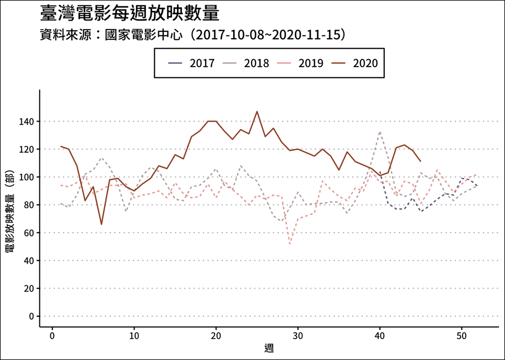

```r
### your code
df_movie_raw %>%
  mutate(year = year(`start_date`), week = week(`start_date`)) %>%
  select(year, week, everything()) %>%
  mutate(`中文片名` = str_remove_all(`中文片名`, " |　")) %>%
  mutate(`中文片名` = str_replace_all(`中文片名`, " ！", "!")) %>%
  group_by(year, week) %>%
  summarise(`放映數量` = n_distinct(`中文片名`)) %>%
  filter(year >= 2017) %>%
  ungroup() %>%
  mutate(year_flag = fct_relevel(if_else(year == 2020, "2020上映", "非2020上映"), "2020上映")) %>%
  ungroup() %>%
  mutate(yw = str_c(year, week, sep = "_"), year = as.factor(year)) %>%
  ggplot(aes(x = week, y = `放映數量`, color = year, group = year, linetype = year_flag)) +
  geom_line(size = 0.6) +
  scale_color_manual(values = c("#736886", "#BDAEAE", "#ECA9A5", "#A0522D")) +
  scale_x_continuous(limits = c(1,52)) +
  scale_y_continuous(limits = c(0,155), breaks = seq(0,140,20)) +
  labs(title="臺灣電影每週放映數量",
       subtitle = "資料來源：國家電影中心（2017-10-08~2020-11-15）",
        x ="週", y = "電影放映數量（部）") +
  theme_clean() +
  scale_linetype(guide = "none") +
  theme(legend.position="top", legend.title = element_blank()) +
  theme(plot.title = element_text(family = "Noto Sans CJK TC Medium", face = "plain", size = 18),
        # legend.title = element_text(family = "Noto Sans CJK TC Medium", face = "plain"),
        legend.text = element_text(family = "Noto Sans CJK TC Medium", face = "plain"),
        text = element_text(family = "Noto Sans CJK TC Medium"))
```

```r
### your result should be
# 自己畫就好唷
```

[figure not shown]

### 2. `geom_bar()` or `geom_col()`:

可以參考 data -> AS04 -> plot_02.jpg，或者直接看 readr 報導當中標題為「臺灣的電影銷售票房變化」的圖表。本題要求和 readr 的數字相同。年份的計算方式可以挑選 **`start_date`** 作為基準。

keywords： `geom_bar/col()`, `year()`, `fill = ?`

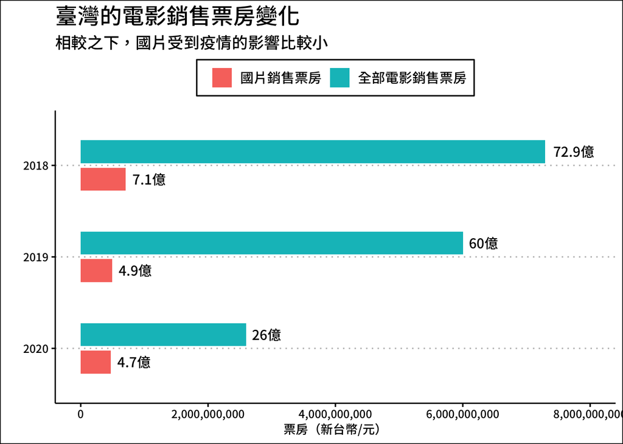

```r
### your code
df_movie_raw %>%
  filter(`國別地區` == "中華民國") %>%
  mutate(year = year(`start_date`)) %>%
  mutate(`中文片名` = str_remove_all(`中文片名`, " |　")) %>%
  mutate(`中文片名` = str_replace_all(`中文片名`, " ！", "!")) %>%
  group_by(year) %>%
  summarise(`銷售票數` = sum(`銷售票數`),
            `銷售金額` = sum(`銷售金額`)) %>%
  filter(year >= 2018) %>%
  ungroup() %>%
  mutate(country_flag = "國片銷售票房") %>%
  bind_rows(
    df_movie_raw %>%
      mutate(year = year(`start_date`)) %>%
      mutate(`中文片名` = str_remove_all(`中文片名`, " |　")) %>%
      mutate(`中文片名` = str_replace_all(`中文片名`, " ！", "!")) %>%
      group_by(year) %>%
      summarise(`銷售票數` = sum(`銷售票數`),
                `銷售金額` = sum(`銷售金額`)) %>%
      filter(year >= 2018) %>%
      ungroup() %>%
      mutate(country_flag = "全部電影銷售票房")
  ) %>%
  mutate(country_flag = fct_relevel(as.factor(country_flag), "國片銷售票房")) %>%
  mutate(year = fct_reorder(as.factor(year), desc(year))) %>%
  mutate(sales_label = str_c(round((`銷售金額`/100000000), 1), "億")) %>%
  ggplot(aes(x = `year`, y = `銷售金額`, fill = country_flag)) +
  geom_col(position = position_dodge(width = 0.6), width=0.5) +
  geom_text(aes(label = sales_label),
            position = position_dodge(width = 0.6), hjust = -0.2,
            family = "Noto Sans CJK TC Medium") +
  coord_flip() +
  scale_y_continuous(limits = c(0,8000000000), labels = scales::comma) +
  # scale_y_continuous(limits = c(0,155), breaks = seq(0,140,20)) +
  labs(title="臺灣的電影銷售票房變化",
       subtitle = "相較之下，國片受到疫情的影響比較小",
        x ="", y = "票房（新台幣/元）") +
  theme_clean() +
  theme(legend.position="top", legend.title = element_blank()) +
  theme(plot.title = element_text(family = "Noto Sans CJK TC Medium", face = "plain", size = 18),
        # legend.title = element_text(family = "Noto Sans CJK TC Medium", face = "plain"),
        legend.text = element_text(family = "Noto Sans CJK TC Medium", face = "plain"),
        text = element_text(family = "Noto Sans CJK TC Medium"))
```

```r
### your result should be
# 自己畫就好唷
```

[figure not shown]

### 3. `geom_bar()` or `geom_col()`:

請參考 readr 的圖表，畫出台灣 2017 - 2020 每年國片上映院數的中位數長條圖。

可以參考 data -> AS04 -> plot_03.jpg，或者直接看 readr 報導當中標題為「國片上映院數是否有增加？」的圖表。本題要求和 readr 的數字相同。上映日期的計算方式可以直接使用 **`上映日期`** 欄位。

keywords： `geom_bar/col()`, `year()`, `fill = ?`

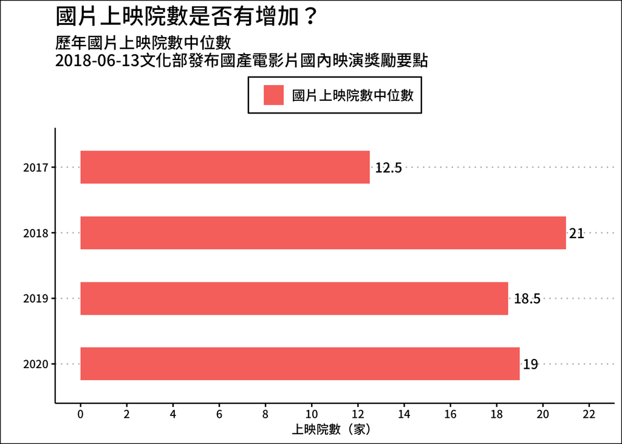

```r
### your code
df_movie_raw %>%
  filter(`國別地區` == "中華民國") %>%
  mutate(year = year(`上映日期`)) %>%
  group_by(year, `中文片名`) %>%
  summarise(`上映院數` = max(`上映院數`)) %>%
  ungroup() %>%
  group_by(year) %>%
  summarise(`上映院數` = median(`上映院數`, na.rm = T)) %>%
  filter(year >= 2017) %>%
  mutate(year = fct_reorder(as.factor(year), desc(year))) %>%
  mutate(rank = row_number()) %>%
  ggplot(aes(x = `year`, y = `上映院數`, fill = "國片上映院數中位數")) +
  geom_col(width=0.5) +
  geom_text(aes(label = `上映院數`),
            hjust = -0.2,
            family = "Noto Sans CJK TC Medium") +
  coord_flip() +
  scale_y_continuous(limits = c(0,22), breaks = seq(0,22,2)) +
  labs(title="國片上映院數是否有增加？",
       subtitle = "歷年國片上映院數中位數\n2018-06-13文化部發布國產電影片國內映演獎勵要點",
        x ="", y = "上映院數（家）") +
  theme_clean() +
  theme(legend.position="top", legend.title = element_blank()) +
  theme(plot.title = element_text(family = "Noto Sans CJK TC Medium", face = "plain", size = 18),
        # legend.title = element_text(family = "Noto Sans CJK TC Medium", face = "plain"),
        legend.text = element_text(family = "Noto Sans CJK TC Medium", face = "plain"),
        text = element_text(family = "Noto Sans CJK TC Medium"))
```

```r
### your result should be
# 自己畫就好唷
```

[figure not shown]

### 4. `geom_bar()` or `geom_col()`:

請參考 readr 的圖表，畫出台灣 2017 - 2020 國片累計銷售金額的長條圖，篩選出銷售金額前 23 高的國片後由大到小排列。（圖表中有部片叫做《可不可以，你也剛好喜歡我》，它是 2020 年上映的，readr 應該漏標了。）

可以參考 data -> AS04 -> plot_04.jpg，或者直接看 readr 報導當中標題為「2017 ~ 2020 熱賣國片前 20 名」的圖表。本題要求和 readr 的數字相同。上映日期的計算方式可以直接使用 **`上映日期`** 欄位。

keywords： `geom_bar/col()`, `year()`, `fill = ?`

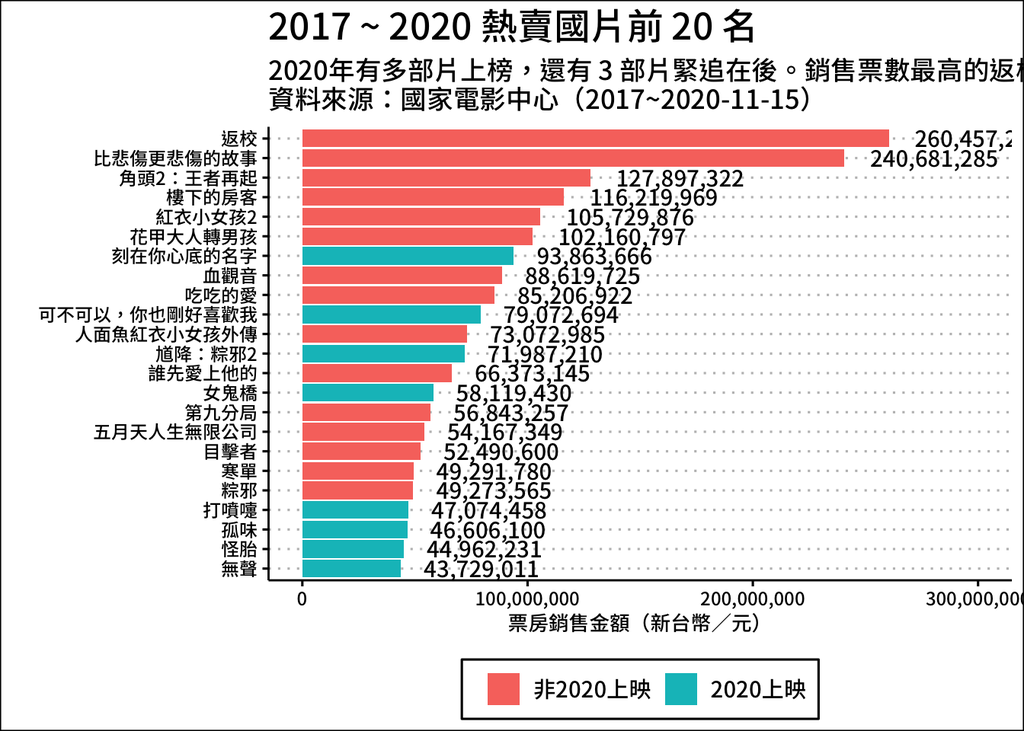

```r
### your code
df_movie_raw %>%
  filter(`國別地區` == "中華民國") %>%
  mutate(`中文片名` = str_remove_all(`中文片名`, " |　")) %>%
  mutate(`中文片名` = str_replace_all(`中文片名`, " ！", "!")) %>%
  mutate(year_flag = fct_relevel(if_else(year(`上映日期`) == 2020, "2020上映", "非2020上映"), "非2020上映")) %>%
  filter(!is.na(`上映日期`)) %>%
  group_by(`中文片名`, year_flag) %>%
  summarise(`累計銷售票數` = max(`累計銷售票數`),
            `累計銷售金額` = max(`累計銷售金額`)) %>%
  arrange(desc(`累計銷售金額`)) %>%
  ungroup() %>%
  slice(1:23) %>%
  mutate(rank = row_number()) %>%
  mutate(`中文片名` = fct_reorder(as.factor(`中文片名`), desc(rank))) %>%
  ggplot(aes(x = `中文片名`, y = `累計銷售金額`, fill = year_flag)) +
  geom_col() +
  geom_text(aes(label = scales::comma(`累計銷售金額`)),
            position = position_dodge(width = 0.6), hjust = -0.2,
            family = "Noto Sans CJK TC Medium") +
  coord_flip() +
  scale_y_continuous(limits = c(0,300000000), labels = scales::comma) +
  labs(title="2017 ~ 2020 熱賣國片前 20 名",
       subtitle = "2020年有多部片上榜，還有 3 部片緊追在後。銷售票數最高的返校，相當於美 20 個臺灣人就有一個人看過。\n資料來源：國家電影中心（2017~2020-11-15）",
        x ="", y = "票房銷售金額（新台幣／元）") +
  theme_clean() +
  theme(legend.position="bottom", legend.title = element_blank()) +
  theme(plot.title = element_text(family = "Noto Sans CJK TC Medium", face = "plain", size = 18),
        # legend.title = element_text(family = "Noto Sans CJK TC Medium", face = "plain"),
        legend.text = element_text(family = "Noto Sans CJK TC Medium", face = "plain"),
        text = element_text(family = "Noto Sans CJK TC Medium"))
```

```r
### your result should be
# 自己畫就好唷
```

[figure not shown]